Window Number 38

----------------------------

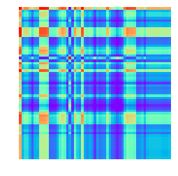

45

A_M1122YF05_2S3RNA

Drowsy True

Window Number 32

----------------------------

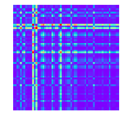

46

A_M1127MM02_2S3RNA

Drowsy True

Window Number 32

----------------------------

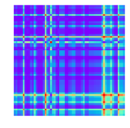

47

A_M1143MF04_2S2RNA

Drowsy True

Window Number 34

----------------------------

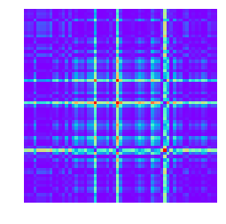

48

A_M1001YM01_1S1RNA

Drowsy False

Window Number 32

----------------------------

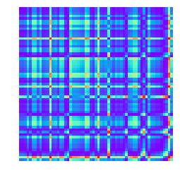

49

A_M1001YM01_1S1RNA

Drowsy False

Window Number 33

----------------------------

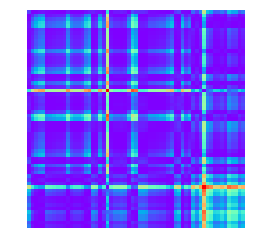

50

A_M1001YM01_1S1RNA

Drowsy False

Window Number 34

----------------------------

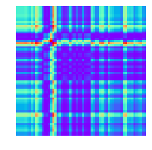

51

A_M1001YM01_1S1RNA

Drowsy False

Window Number 35

----------------------------

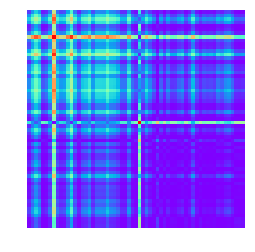

52

A_M1001YM01_1S1RNA

Drowsy False

Window Number 36

----------------------------

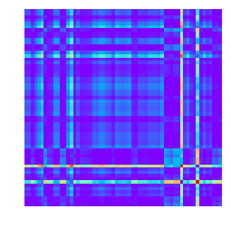

53

A_M1001YM01_1S1RNA

Drowsy False

Window Number 37

----------------------------

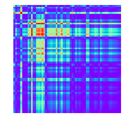

54

A_M1001YM01_1S1RNA

Drowsy False

Window Number 38

----------------------------

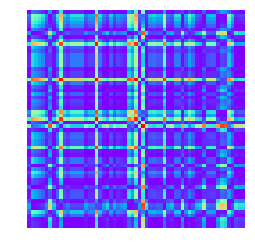

55

A_M1001YM01_1S1RNA

Drowsy False

Window Number 39

----------------------------

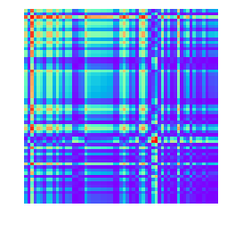

56

A_M1001YM01_1S1RNA

Drowsy False

Window Number 40

----------------------------

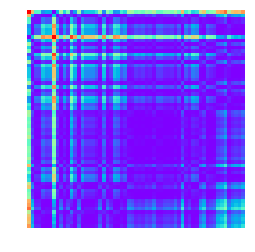

57

A_M1003YM02_1S2RNA

Drowsy False

Window Number 31

----------------------------

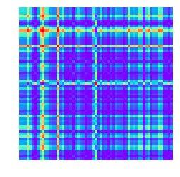

58

A_M1003YM02_1S2RNA

Drowsy False

Window Number 32

----------------------------

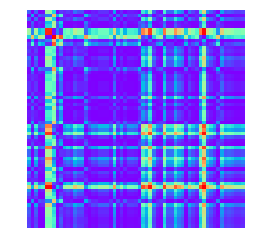

59

A_M1003YM02_1S2RNA

Drowsy False

Window Number 33

----------------------------

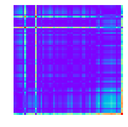

60

A_M1003YM02_1S2RNA

Drowsy False

Window Number 34

----------------------------

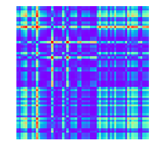

61

A_M1003YM02_1S2RNA

Drowsy False

Window Number 35

----------------------------

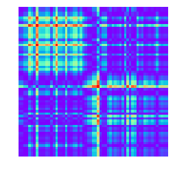

62

A_M1003YM02_1S2RNA

Drowsy False

Window Number 36

----------------------------

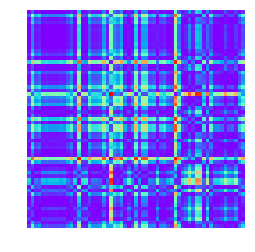

63

A_M1003YM02_1S2RNA

Drowsy False

Window Number 37

----------------------------

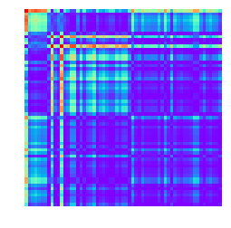

64

A_M1003YM02_1S2RNA

Drowsy False

Window Number 38

----------------------------

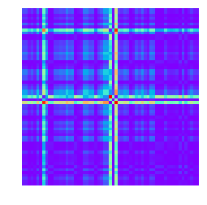

65

A_M1003YM02_1S2RNA

Drowsy False

Window Number 39

----------------------------

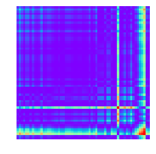

66

A_M1003YM02_1S2RNA

Drowsy False

Window Number 40

----------------------------

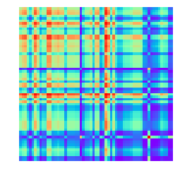

67

A_M1014YF01_3S3RNA

Drowsy False

Window Number 29

----------------------------

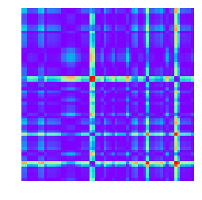

68

A_M1014YF01_3S3RNA

Drowsy False

Window Number 30

----------------------------

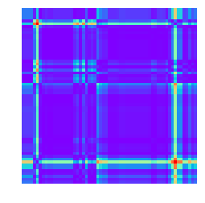

69

A_M1014YF01_3S3RNA

Drowsy False

Window Number 31

----------------------------

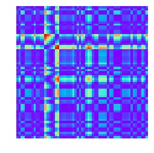

70

A_M1014YF01_3S3RNA

Drowsy False

Window Number 32

----------------------------

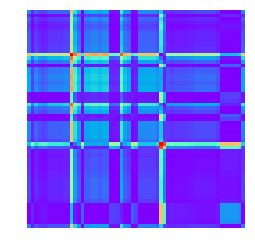

71

A_M1014YF01_3S3RNA

Drowsy False

Window Number 33

----------------------------

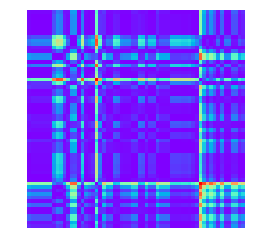

72

A_M1014YF01_3S3RNA

Drowsy False

Window Number 34

----------------------------

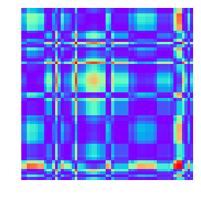

73

A_M1014YF01_3S3RNA

Drowsy False

Window Number 35

----------------------------

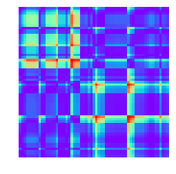

74

A_M1014YF01_3S3RNA

Drowsy False

Window Number 36

----------------------------

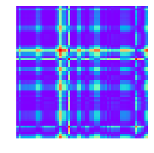

75

A_M1014YF01_3S3RNA

Drowsy False

Window Number 37

----------------------------

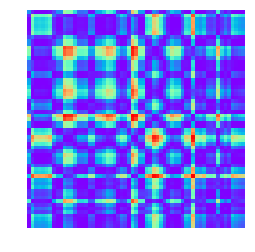

76

A_M1014YF01_3S3RNA

Drowsy False

Window Number 38

----------------------------

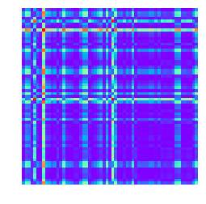

77

A_M1016YF02_1S2RNA

Drowsy False

Window Number 33

----------------------------

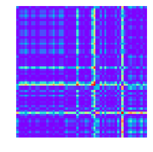

78

A_M1016YF02_1S2RNA

Drowsy False

Window Number 34

----------------------------

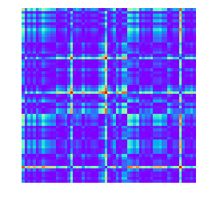

79

A_M1016YF02_1S2RNA

Drowsy False

Window Number 35

----------------------------

In [9]: